# Environmental Audio AI Examples

**Toni Heittola**  
toni.heittola@tuni.fi

# Introduction

This presentation goes through the usage of **pretrained models** for sound classification and **adapting them** for specific tasks

## Outline

- Audio tagging with pretrained models:
  - PANNS
  - YAMNet
- Transfer learning with pretrained models
- Sound event detection

# PANNS

**Large-scale pretrained audio neural networks for audio pattern recognition**

- State-of-the-art pretrained audio tagging model released in 2019
- Model architecture is inspired by [VGG](https://arxiv.org/abs/1409.1556) architecture, model (CNN14) has **80M parameters**
- Trained with [AudioSet](https://research.google.com/audioset/) dataset
  - Data collected from YouTube
  - 2M human-labeled 10-second clips organized into ontology with 632 sound classes
- Designed for single-channel audio with a 32kHz sampling rate
- Model outputs:
  - Score for **527 sound classes**
  - Per-analysis-frame embedding (2048 values)
- Two modes: Audio tagger and Sound event detector

Qiuqiang Kong, Yin Cao, Turab Iqbal, Yuxuan Wang, Wenwu Wang, and Mark D. Plumbley. "**PANNS: Large-scale pretrained audio neural networks for audio pattern recognition.**" IEEE/ACM Transactions on Audio, Speech, and Language Processing 28 (2020): 2880-2894. [PDF](https://arxiv.org/pdf/1912.10211.pdf)

## Example audio

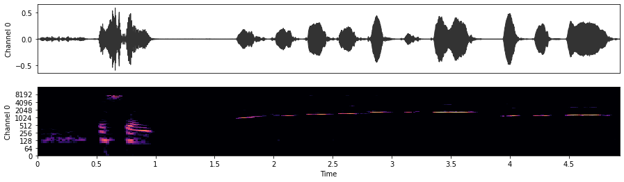

[interactive chart not shown]

## Usage as audio tagger

```python
# Import
from panns_inference import AudioTagging, labels

# Create audio tagger
audio_tagger = AudioTagging(
    checkpoint_path=model_storage_filename,
    device='cuda'
)
# Apply to test audio
(clipwise_output, embeddings) = audio_tagger.inference(
    test_audio_32k.data[None, :] # (batch_size, audio_samples)
)
```

Top 5 tags based on outputted scores:

```
Score Tag
----- -------
0.724 Whistle
0.453 Whistling
0.334 Speech
0.079 Music
0.053 Inside, small room
```

## Usage as a sound event detector

```python
# Import
from panns_inference import SoundEventDetection, labels

# Create sound event detector
detector = SoundEventDetection(
    checkpoint_path=model_storage_filename,
    device='cuda'
)
# Apply to test audio
framewise_output = detector.inference(test_audio_32k.data[None, :])
```

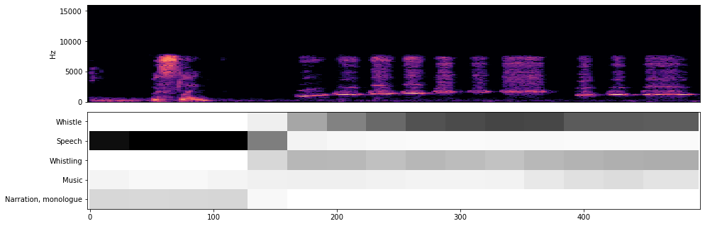

# YAMNet

**Pretrained neural network for sound recognition**

## Usage

```python
# Import
import tensorflow_hub as hub

# Load model
yamnet_model_handle = 'https://tfhub.dev/google/yamnet/1'
yamnet_model = hub.load(yamnet_model_handle)

# Load class names
class_map_path = yamnet_model.class_map_path().numpy().decode('utf-8')
class_names = list(pd.read_csv(class_map_path)['display_name'])

# Run the model, check the output.
scores, embeddings, spectrogram = yamnet_model(test_audio_16k.data)
```

```
scores matrix shape (analysis segments, class-wise scores):
 (10, 521)
```

## Example audio

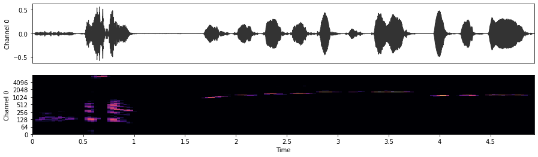

[interactive chart not shown]

## Analyze content

```python
# Run the model
scores, embeddings, spectrogram_data = yamnet_model(test_audio_16k.data)

# Get top class
infered_class = class_names[scores.numpy().mean(axis=0).argmax()]
```

```
infered_class: Whistle
```

## Scores of the top 5 classes across the sample

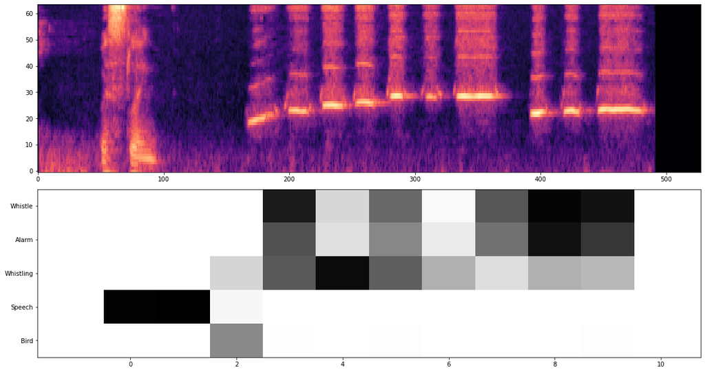

# Transfer Learning

*We need to make a robust classifier, however, we only have small amount of examples per class*

[figure not shown]

## Transfer Learning

**Advantage**: Many pre-trained models available, enables including a large amount of knowledge into the learning process with minimal computational power

**Disadvantage**: No guarantee that it works; in some cases can make the learning process even harder (negative transfer)

## Application example

**Target task**: Animal vocalization classifier with 10 classes

**Source task**: Generic sound classifier YAMNet

A new model will be trained, and YAMNet embeddings will be used as input features

## Application

[ESC-50 dataset](https://github.com/karolpiczak/ESC-50) will be used as target data

- 5-second environmental audio recordings collected from [FreeSound.org](https://freesound.org/)
- Recordings are organized into 50 classes each having 40 examples

```python
target_classes = [
    'cat',       # YAMNet class
    'cow',
    'crickets',
    'crow',      # YAMNet class
    'dog',       # YAMNet class
    'frog',      # YAMNet class
    'hen',
    'pig',       # YAMNet class
    'rooster',
    'sheep'      # YAMNet class
]
```

Only six of the target classes could be recognized directly by YAMNet.

## Select material from ESC-50 dataset

Identify suitable items in the dataset

```python
# Load dataset meta
dataset_meta = pd.read_csv(meta_csv)

# Filter data
dataset_meta_filtered = dataset_meta[dataset_meta.category.isin(target_classes)]
class_id = dataset_meta_filtered['category'].apply(
    lambda name: map_class_to_id[name]
)
dataset_meta_filtered = dataset_meta_filtered.assign(target=class_id)
```

|  | filename | category |
| --- | --- | --- |
| 0 | data/datasets/ESC-50-master/audio16k/1-100032-... | dog |
| 8 | data/datasets/ESC-50-master/audio16k/1-103298-... | crow |
| 14 | data/datasets/ESC-50-master/audio16k/1-110389-... | dog |
| 29 | data/datasets/ESC-50-master/audio16k/1-121951-... | sheep |
| 45 | data/datasets/ESC-50-master/audio16k/1-15689-A... | frog |

## Extract embeddings

```python
main_ds = tf.data.Dataset.from_tensor_slices(
    (dataset_meta_filtered['filename'],
     dataset_meta_filtered['target'],
     dataset_meta_filtered['fold'])
)

def load_audio_for_map_function(filename, label, fold):
  return load_audio(filename), label, fold

main_ds = main_ds.map(load_audio_for_map_function)

# Function to extract embeddings
def extract_embedding(wav_data, label, fold):
  scores, embeddings, spectrogram = yamnet_model(wav_data)
  num_embeddings = tf.shape(embeddings)[0]
  return (embeddings,
          tf.repeat(label, num_embeddings),
          tf.repeat(fold, num_embeddings))

# Extract embedding
main_ds = main_ds.map(extract_embedding).unbatch()
```

## Create neural network

```python
finetuned_model = tf.keras.Sequential([
    tf.keras.layers.Input(
        shape=(1024),
        dtype=tf.float32,
        name='input_embedding'
    ),
    tf.keras.layers.Dense(512, activation='relu', name='fully-connected'),
    tf.keras.layers.Dense(len(target_classes), name='output')
], name='my_model')
```

Model summary

| Layer name | Layer type | Output shape | Parameters |
| --- | --- | --- | --- |
| fully-connected | Dense | (None, 512) | 524800 |
| output | Dense | (None, 10) | 5130 |

## Training

```python
finetuned_model.compile(
    loss=tf.keras.losses.SparseCategoricalCrossentropy(from_logits=True),
    optimizer='adam',
    metrics=['accuracy']
)

callback = tf.keras.callbacks.EarlyStopping(monitor='loss', patience=10, restore_best_weights=True)

# Track power consumption and time
tracker = EmissionsTracker("Transfer learning example", output_dir=os.path.join('data', 'training_codecarbon'))
tracker.start()
start_time = time.time()

history = finetuned_model.fit(train_ds, epochs=100, validation_data=val_ds, callbacks=callback, verbose=0)

# Stop tracking
stop_time = time.time()
tracker.stop()
```

```
Time used for training: 28.55 sec
Total energy consumed during training: 0.00083 kWh
```

## Evaluation

| Scene label | Accuracy |
| --- | --- |
| cat | 100.0 |
| cow | 100.0 |
| crickets | 87.5 |
| crow | 100.0 |
| dog | 100.0 |
| frog | 62.5 |
| hen | 100.0 |
| pig | 62.5 |
| rooster | 100.0 |
| sheep | 100.0 |
| Average | 91.2 |

### Confusion matrix

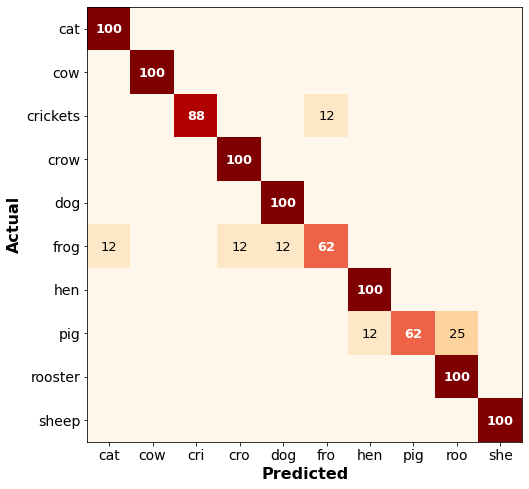

# Sound Event Detection

*The task of simultaneously estimating what is happening and when it is happening*

[figure not shown]

## System structure

A *simple* sound event detector can be implemented by applying a sound classifier or audio tagger in consecutive segments and joining activity information into sound events with start and end times.

- Model trained in the transfer learning section will be used
- Analysis is done in segments (0.96 sec) that are moved through the signal with 0.5-sec hops
- In each segment, the model is used to get class-wise scores
- Class with the highest score is outputted if the score is over the threshold (0.99)
- This system can detect only a single sound event at a time with a time resolution of 0.5 sec

## Example input signal

Signal generated with *dog*, *cat*, *rooster*, and *cow* samples in a metro station

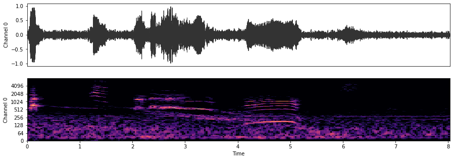

[interactive chart not shown]

## System output versus reference

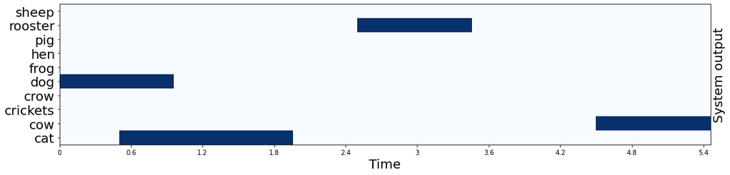

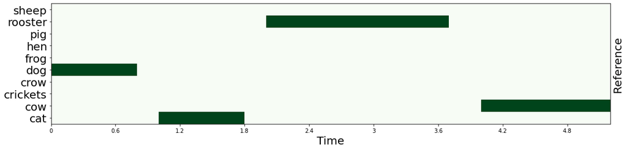